```python
import pandas as pd
import numpy as np
import matplotlib.pyplot as plt
import seaborn as sns

%matplotlib inline

import warnings
warnings.simplefilter("ignore")
from sklearn.preprocessing import MinMaxScaler
from sklearn.preprocessing import StandardScaler
from sklearn.preprocessing import LabelEncoder
from sklearn.model_selection import train_test_split, GridSearchCV
from sklearn.metrics import confusion_matrix, accuracy_score, classification_report, roc_curve, roc_auc_score
from xgboost import XGBClassifier
```

# Data Understanding & Exploration:

Read ‘TelcomCustomer-Churn_1.csv’ as a DataFrame and assign it to a variable.

```python
data1 = pd.read_csv("TelcomCustomer-Churn_1.csv")
data1.head()
```

|  | customerID | gender | SeniorCitizen | Partner | Dependents | tenure | PhoneService | MultipleLines | InternetService | OnlineSecurity |
| --- | --- | --- | --- | --- | --- | --- | --- | --- | --- | --- |
| 0 | 7590-VHVEG | Female | 0 | Yes | No | 1 | No | No phone service | DSL | No |
| 1 | 5575-GNVDE | Male | 0 | No | No | 34 | Yes | No | DSL | Yes |
| 2 | 3668-QPYBK | Male | 0 | No | No | 2 | Yes | No | DSL | Yes |
| 3 | 7795-CFOCW | Male | 0 | No | No | 45 | No | No phone service | DSL | Yes |
| 4 | 9237-HQITU | Female | 0 | No | No | 2 | Yes | No | Fiber optic | No |

Read ‘TelcomCustomer-Churn_2.csv’ as a DataFrame and assign it to a variable.

```python
data2 = pd.read_csv("TelcomCustomer-Churn_2.csv")
data2.head()
```

|  | customerID | OnlineBackup | DeviceProtection | TechSupport | StreamingTV | StreamingMovies | Contract | PaperlessBilling | PaymentMethod | MonthlyCharges | TotalCharges | Churn |
| --- | --- | --- | --- | --- | --- | --- | --- | --- | --- | --- | --- | --- |
| 0 | 7590-VHVEG | Yes | No | No | No | No | Month-to-month | Yes | Electronic check | 29.85 | 29.85 | No |
| 1 | 5575-GNVDE | No | Yes | No | No | No | One year | No | Mailed check | 56.95 | 1889.5 | No |
| 2 | 3668-QPYBK | Yes | No | No | No | No | Month-to-month | Yes | Mailed check | 53.85 | 108.15 | Yes |
| 3 | 7795-CFOCW | No | Yes | Yes | No | No | One year | No | Bank transfer (automatic) | 42.30 | 1840.75 | No |
| 4 | 9237-HQITU | No | No | No | No | No | Month-to-month | Yes | Electronic check | 70.70 | 151.65 | Yes |

Merge both the DataFrames on key ‘customerID’ to form a single DataFrame

```python
data = data1.merge(data2,left_on='customerID',right_on='customerID')
data.head()
```

|  | customerID | gender | SeniorCitizen | Partner | Dependents | tenure | PhoneService | MultipleLines | InternetService | OnlineSecurity | ... | DeviceProtection | TechSupport | StreamingTV | StreamingMovies | Contract | PaperlessBilling | PaymentMethod | MonthlyCharges | TotalCharges | Churn |
| --- | --- | --- | --- | --- | --- | --- | --- | --- | --- | --- | --- | --- | --- | --- | --- | --- | --- | --- | --- | --- | --- |
| 0 | 7590-VHVEG | Female | 0 | Yes | No | 1 | No | No phone service | DSL | No | ... | No | No | No | No | Month-to-month | Yes | Electronic check | 29.85 | 29.85 | No |
| 1 | 5575-GNVDE | Male | 0 | No | No | 34 | Yes | No | DSL | Yes | ... | Yes | No | No | No | One year | No | Mailed check | 56.95 | 1889.5 | No |
| 2 | 3668-QPYBK | Male | 0 | No | No | 2 | Yes | No | DSL | Yes | ... | No | No | No | No | Month-to-month | Yes | Mailed check | 53.85 | 108.15 | Yes |
| 3 | 7795-CFOCW | Male | 0 | No | No | 45 | No | No phone service | DSL | Yes | ... | Yes | Yes | No | No | One year | No | Bank transfer (automatic) | 42.30 | 1840.75 | No |
| 4 | 9237-HQITU | Female | 0 | No | No | 2 | Yes | No | Fiber optic | No | ... | No | No | No | No | Month-to-month | Yes | Electronic check | 70.70 | 151.65 | Yes |

5 rows × 21 columns

```python
data.info()
```

```
<class 'pandas.core.frame.DataFrame'>
Int64Index: 7043 entries, 0 to 7042
Data columns (total 21 columns):
 #   Column            Non-Null Count  Dtype
---  ------            --------------  -----
 0   customerID        7043 non-null   object
 1   gender            7043 non-null   object
 2   SeniorCitizen     7043 non-null   int64
 3   Partner           7043 non-null   object
 4   Dependents        7043 non-null   object
 5   tenure            7043 non-null   int64
 6   PhoneService      7043 non-null   object
 7   MultipleLines     7043 non-null   object
 8   InternetService   7043 non-null   object
 9   OnlineSecurity    7043 non-null   object
 10  OnlineBackup      7043 non-null   object
 11  DeviceProtection  7043 non-null   object
 12  TechSupport       7043 non-null   object
 13  StreamingTV       7043 non-null   object
 14  StreamingMovies   7043 non-null   object
 15  Contract          7043 non-null   object
 16  PaperlessBilling  7043 non-null   object
 17  PaymentMethod     7043 non-null   object
 18  MonthlyCharges    7043 non-null   float64
 19  TotalCharges      7043 non-null   object
 20  Churn             7043 non-null   object
dtypes: float64(1), int64(2), object(18)
memory usage: 1.2+ MB
```

**Verify if all the columns are incorporated in the merged DataFrame by using simple comparison Operator in Python.**

```python
print(data1[~data1['customerID'].isin(data['customerID'])])
```

```
Empty DataFrame
Columns: [customerID, gender, SeniorCitizen, Partner, Dependents, tenure, PhoneService, MultipleLines, InternetService, OnlineSecurity]
Index: []
```

```python
print(data2[~data2['customerID'].isin(data['customerID'])])
```

```
Empty DataFrame
Columns: [customerID, OnlineBackup, DeviceProtection, TechSupport, StreamingTV, StreamingMovies, Contract, PaperlessBilling, PaymentMethod, MonthlyCharges, TotalCharges, Churn]
Index: []
```

```python
data.columns
```

```
Index(['customerID', 'gender', 'SeniorCitizen', 'Partner', 'Dependents',
       'tenure', 'PhoneService', 'MultipleLines', 'InternetService',
       'OnlineSecurity', 'OnlineBackup', 'DeviceProtection', 'TechSupport',
       'StreamingTV', 'StreamingMovies', 'Contract', 'PaperlessBilling',
       'PaymentMethod', 'MonthlyCharges', 'TotalCharges', 'Churn'],
      dtype='object')
```

""

**Data Cleaning & Analysis:**

Impute missing/unexpected values in the DataFrame.

```python
data.dtypes
```

```
customerID           object
gender               object
SeniorCitizen         int64
Partner              object
Dependents           object
tenure                int64
PhoneService         object
MultipleLines        object
InternetService      object
OnlineSecurity       object
OnlineBackup         object
DeviceProtection     object
TechSupport          object
StreamingTV          object
StreamingMovies      object
Contract             object
PaperlessBilling     object
PaymentMethod        object
MonthlyCharges      float64
TotalCharges         object
Churn                object
dtype: object
```

Totalcharges column originally was an object hence had to be changed to float/numeric value

```python
data.TotalCharges = pd.to_numeric(data.TotalCharges, errors='coerce')
data.isnull().sum()
```

```
customerID           0
gender               0
SeniorCitizen        0
Partner              0
Dependents           0
tenure               0
PhoneService         0
MultipleLines        0
InternetService      0
OnlineSecurity       0
OnlineBackup         0
DeviceProtection     0
TechSupport          0
StreamingTV          0
StreamingMovies      0
Contract             0
PaperlessBilling     0
PaymentMethod        0
MonthlyCharges       0
TotalCharges        11
Churn                0
dtype: int64
```

11 Null/Missing values in total charges column. We will drop/remove the missing values since the count is low.

```python
data.dropna(inplace = True)
```

```python
data.isnull().sum()
```

```
customerID          0
gender              0
SeniorCitizen       0
Partner             0
Dependents          0
tenure              0
PhoneService        0
MultipleLines       0
InternetService     0
OnlineSecurity      0
OnlineBackup        0
DeviceProtection    0
TechSupport         0
StreamingTV         0
StreamingMovies     0
Contract            0
PaperlessBilling    0
PaymentMethod       0
MonthlyCharges      0
TotalCharges        0
Churn               0
dtype: int64
```

```python
data = data.drop(['customerID'],axis=1)
```

```python
def Categorical_pie_charts(data,m):
    a = []
    for i in data:
        a.append(i)

    b = []
    for i in a:
        if (data[i].dtype.name) == 'object':
            b.append(i)

    plt.figure(figsize=(20, 25))
    plt.subplots_adjust(hspace=0.5)
    plt.suptitle("Pie-Charts for Categorical Variables in the dataframe", fontsize=18, y=0.95)

    ncols = m
    nrows = len(b) // ncols + (len(b) % ncols > 0)

    for n, i in enumerate(b):
        ax = plt.subplot(nrows, ncols, n + 1)

        data.groupby(i).size().plot(kind='pie', autopct='%.2f%%',ax=ax)

        ax.set_title(i.upper())
        ax.set_xlabel("")
        ax.set_ylabel("")
    plt.show()
```

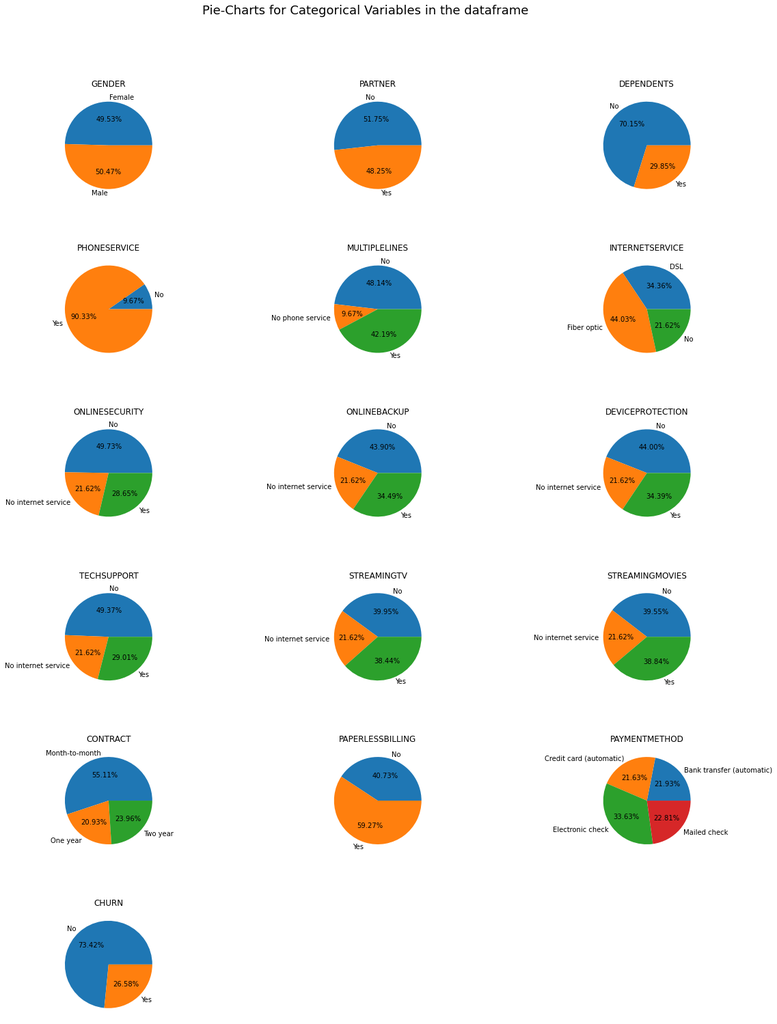

```python
Categorical_pie_charts(data,3)
```

**Share insights for Q2.c**

-->Churn: 26.6 % of customers switched to another firm based on churn pie chart.

-->Gender Ratio: Customers are 49.5 % female and 50.5 % male.

-->Contract: High number of contracts of month to month basis than higher tenures of 1-2 years

-->Payment method: Electronic check and mailed cheque have high percentage as compared to automatic payment methods. People with automatic payment methods are less likely to move out.

-->Paperless billing: High percentage of customers opted for paperless billing.

-->Percentage of no internet service in columns like Online security, online backup,device protection, techsupport, streaming TV and streaming movies is exactly same and percentage of users who have not opted for these services is high as compared to users who have opted.

--> More numbers of users are without parters or dependents

-->Most of the users have opted for fiberoptic internet service as compared to others like DSL

**Encode all the appropriate Categorical features with the best suitable approach**

```python
data.head()
```

|  | gender | SeniorCitizen | Partner | Dependents | tenure | PhoneService | MultipleLines | InternetService | OnlineSecurity | OnlineBackup | DeviceProtection | TechSupport | StreamingTV | StreamingMovies | Contract | PaperlessBilling | PaymentMethod | MonthlyCharges | TotalCharges | Churn |
| --- | --- | --- | --- | --- | --- | --- | --- | --- | --- | --- | --- | --- | --- | --- | --- | --- | --- | --- | --- | --- |
| 0 | Female | 0 | Yes | No | 1 | No | No phone service | DSL | No | Yes | No | No | No | No | Month-to-month | Yes | Electronic check | 29.85 | 29.85 | No |
| 1 | Male | 0 | No | No | 34 | Yes | No | DSL | Yes | No | Yes | No | No | No | One year | No | Mailed check | 56.95 | 1889.50 | No |
| 2 | Male | 0 | No | No | 2 | Yes | No | DSL | Yes | Yes | No | No | No | No | Month-to-month | Yes | Mailed check | 53.85 | 108.15 | Yes |
| 3 | Male | 0 | No | No | 45 | No | No phone service | DSL | Yes | No | Yes | Yes | No | No | One year | No | Bank transfer (automatic) | 42.30 | 1840.75 | No |
| 4 | Female | 0 | No | No | 2 | Yes | No | Fiber optic | No | No | No | No | No | No | Month-to-month | Yes | Electronic check | 70.70 | 151.65 | Yes |

```python
print(data.gender.value_counts())
print(data.SeniorCitizen.value_counts())
print(data.Partner.value_counts())
print(data.Dependents.value_counts())
print(data.tenure.value_counts())
print(data.PhoneService.value_counts())
print(data.MultipleLines.value_counts())
print(data.OnlineSecurity.value_counts())
print(data.OnlineBackup.value_counts())
print(data.DeviceProtection.value_counts())
print(data.TechSupport.value_counts())
print(data.StreamingTV.value_counts())
print(data.StreamingMovies.value_counts())
print(data.Contract.value_counts())
print(data.PaperlessBilling	.value_counts())
print(data.PaymentMethod.value_counts())
print(data.Churn.value_counts())
```

```
Male      3549
Female    3483
Name: gender, dtype: int64
0    5890
1    1142
Name: SeniorCitizen, dtype: int64
No     3639
Yes    3393
Name: Partner, dtype: int64
No     4933
Yes    2099
Name: Dependents, dtype: int64
1     613
72    362
2     238
3     200
4     176
     ...
38     59
28     57
39     56
44     51
36     50
Name: tenure, Length: 72, dtype: int64
Yes    6352
No      680
Name: PhoneService, dtype: int64
No                  3385
Yes                 2967
No phone service     680
Name: MultipleLines, dtype: int64
No                     3497
Yes                    2015
No internet service    1520
Name: OnlineSecurity, dtype: int64
No                     3087
Yes                    2425
No internet service    1520
Name: OnlineBackup, dtype: int64
No                     3094
```

[output cut: 15 more lines]

```
Month-to-month    3875
Two year          1685
One year          1472
Name: Contract, dtype: int64
Yes    4168
No     2864
Name: PaperlessBilling, dtype: int64
Electronic check             2365
Mailed check                 1604
Bank transfer (automatic)    1542
Credit card (automatic)      1521
Name: PaymentMethod, dtype: int64
No     5163
Yes    1869
Name: Churn, dtype: int64
```

```python
#Defining the map function
def bin_map(feature):
    return feature.map({'Yes':1, 'No':0})

## Encoding target feature
data['Churn'] = data[['Churn']].apply(bin_map)

# Encoding gender category
data['gender'] = data['gender'].map({'Male':1, 'Female':0})

#Encoding other binary category
bin_list = ['Partner', 'Dependents', 'PhoneService', 'PaperlessBilling']
data[bin_list] = data[bin_list].apply(bin_map)

#Encoding the other categoric features with more than two categories
data = pd.get_dummies(data, drop_first=True)
```

```python
data.head()
```

|  | gender | SeniorCitizen | Partner | Dependents | tenure | PhoneService | PaperlessBilling | MonthlyCharges | TotalCharges | Churn | ... | TechSupport_Yes | StreamingTV_No internet service | StreamingTV_Yes | StreamingMovies_No internet service | StreamingMovies_Yes | Contract_One year | Contract_Two year | PaymentMethod_Credit card (automatic) | PaymentMethod_Electronic check | PaymentMethod_Mailed check |
| --- | --- | --- | --- | --- | --- | --- | --- | --- | --- | --- | --- | --- | --- | --- | --- | --- | --- | --- | --- | --- | --- |
| 0 | 0 | 0 | 1 | 0 | 1 | 0 | 1 | 29.85 | 29.85 | 0 | ... | 0 | 0 | 0 | 0 | 0 | 0 | 0 | 0 | 1 | 0 |
| 1 | 1 | 0 | 0 | 0 | 34 | 1 | 0 | 56.95 | 1889.50 | 0 | ... | 0 | 0 | 0 | 0 | 0 | 1 | 0 | 0 | 0 | 1 |
| 2 | 1 | 0 | 0 | 0 | 2 | 1 | 1 | 53.85 | 108.15 | 1 | ... | 0 | 0 | 0 | 0 | 0 | 0 | 0 | 0 | 0 | 1 |
| 3 | 1 | 0 | 0 | 0 | 45 | 0 | 0 | 42.30 | 1840.75 | 0 | ... | 1 | 0 | 0 | 0 | 0 | 1 | 0 | 0 | 0 | 0 |
| 4 | 0 | 0 | 0 | 0 | 2 | 1 | 1 | 70.70 | 151.65 | 1 | ... | 0 | 0 | 0 | 0 | 0 | 0 | 0 | 0 | 1 | 0 |

5 rows × 31 columns

**Normalize/Standardize the data with the best suitable approach.**

```python
scaler = MinMaxScaler()
data['tenure'] = scaler.fit_transform(data[['tenure']])
data['MonthlyCharges'] = scaler.fit_transform(data[['MonthlyCharges']])
data['TotalCharges'] = scaler.fit_transform(data[['TotalCharges']])
```

**Split the data into 80% train and 20% test.**

```python
X = data.drop("Churn",axis=1)
y = data["Churn"]
X_train,X_test,y_train, y_test = train_test_split(X,y,test_size=.20, random_state=1 )
```

**Model building and Improvement**

Train a model using XGBoost. Also print best performing parameters along with train and test performance.

```python
model = XGBClassifier(random_state=123)
model.fit(X_train, y_train)
y_train_predic = model.predict(X_train)
y_test_predic = model.predict(X_test)

print(model)
print('Train performance')
print('-------------------------------------------------------')
print(classification_report(y_train, y_train_predic))

print('Test performance')
print('-------------------------------------------------------')
print(classification_report(y_test, y_test_predic))
```

```
XGBClassifier(base_score=0.5, booster='gbtree', callbacks=None,
              colsample_bylevel=1, colsample_bynode=1, colsample_bytree=1,
              early_stopping_rounds=None, enable_categorical=False,
              eval_metric=None, gamma=0, gpu_id=-1, grow_policy='depthwise',
              importance_type=None, interaction_constraints='',
              learning_rate=0.300000012, max_bin=256, max_cat_to_onehot=4,
              max_delta_step=0, max_depth=6, max_leaves=0, min_child_weight=1,
              missing=nan, monotone_constraints='()', n_estimators=100,
              n_jobs=0, num_parallel_tree=1, predictor='auto', random_state=123,
              reg_alpha=0, reg_lambda=1, ...)
Train performance
-------------------------------------------------------
              precision    recall  f1-score   support

           0       0.94      0.97      0.95      4122
           1       0.90      0.82      0.86      1503

    accuracy                           0.93      5625
   macro avg       0.92      0.89      0.91      5625
weighted avg       0.93      0.93      0.93      5625

Test performance
-------------------------------------------------------
              precision    recall  f1-score   support

           0       0.84      0.89      0.86      1041
           1       0.62      0.51      0.56       366

    accuracy                           0.79      1407
   macro avg       0.73      0.70      0.71      1407
weighted avg       0.78      0.79      0.78      1407
```

```python
print(confusion_matrix(y_test, y_test_predic))
```

```
[[926 115]
 [179 187]]
```

Accuracy for test is low, we will try different parameters to see if it changes

**Improve performance of the XGBoost as much as possible. Also print best performing parameters along with train and test performance.**

```python
model_xgb2 = XGBClassifier(silent=False,
                      scale_pos_weight=1,
                      learning_rate=0.01,
                      colsample_bytree = 0.4,
                      subsample = 0.8,
                      objective='binary:logistic',
                      n_estimators=500,
                      reg_alpha = 0.3,
                      max_depth=5,
                      gamma=10)
```

```python
model_xgb2.fit(X_train, y_train)
y_train_predic1 = model_xgb2.predict(X_train)
y_test_predic1 = model_xgb2.predict(X_test)
print(model)
print('Train performance')
print('-------------------------------------------------------')
print(classification_report(y_train, y_train_predic1))

print('Test performance')
print('-------------------------------------------------------')
print(classification_report(y_test, y_test_predic1))
print(confusion_matrix(y_test, y_test_predic1))
```

```
[22:26:37] WARNING: C:/Users/Administrator/workspace/xgboost-win64_release_1.6.0/src/learner.cc:627:
Parameters: { "silent" } might not be used.

  This could be a false alarm, with some parameters getting used by language bindings but
  then being mistakenly passed down to XGBoost core, or some parameter actually being used
  but getting flagged wrongly here. Please open an issue if you find any such cases.


XGBClassifier(base_score=0.5, booster='gbtree', callbacks=None,
              colsample_bylevel=1, colsample_bynode=1, colsample_bytree=1,
              early_stopping_rounds=None, enable_categorical=False,
              eval_metric=None, gamma=0, gpu_id=-1, grow_policy='depthwise',
              importance_type=None, interaction_constraints='',
              learning_rate=0.300000012, max_bin=256, max_cat_to_onehot=4,
              max_delta_step=0, max_depth=6, max_leaves=0, min_child_weight=1,
              missing=nan, monotone_constraints='()', n_estimators=100,
              n_jobs=0, num_parallel_tree=1, predictor='auto', random_state=123,
              reg_alpha=0, reg_lambda=1, ...)
Train performance
-------------------------------------------------------
              precision    recall  f1-score   support

           0       0.84      0.92      0.88      4122
           1       0.70      0.52      0.60      1503

    accuracy                           0.81      5625
   macro avg       0.77      0.72      0.74      5625
weighted avg       0.80      0.81      0.80      5625

Test performance
-------------------------------------------------------
              precision    recall  f1-score   support

           0       0.84      0.91      0.87      1041
           1       0.67      0.49      0.57       366

    accuracy                           0.81      1407
   macro avg       0.75      0.70      0.72      1407
weighted avg       0.79      0.81      0.79      1407

[[952  89]
 [185 181]]
```

Hyperparameter tuning to find out best paramters although the performance has improved on test already

```python
XGBClassifier().get_params().keys()
```

```
dict_keys(['objective', 'use_label_encoder', 'base_score', 'booster', 'callbacks', 'colsample_bylevel', 'colsample_bynode', 'colsample_bytree', 'early_stopping_rounds', 'enable_categorical', 'eval_metric', 'gamma', 'gpu_id', 'grow_policy', 'importance_type', 'interaction_constraints', 'learning_rate…
```

**Hyperparameter Tuning**

```python
params = {
    'n_estimators': [100, 200, 500],
    'learning_rate': [0.01,0.05,0.1],
    'booster': ['gbtree', 'gblinear'],
    'gamma': [0, 0.5, 1],
    'reg_alpha': [0, 0.5, 1],
    'reg_lambda': [0.5, 1, 5],
    'base_score': [0.2, 0.5, 1]
}

grid_s = GridSearchCV(XGBClassifier(n_jobs=-1), params, n_jobs=-1, cv=3, scoring='accuracy',error_score=0)
grid_s.fit(X_train, y_train)

print('Best score:', grid_s.best_score_)
print('Best params:', grid_s.best_params_)
```

```
Best score: 0.8012444444444444
Best params: {'base_score': 0.5, 'booster': 'gbtree', 'gamma': 0, 'learning_rate': 0.01, 'n_estimators': 200, 'reg_alpha': 0, 'reg_lambda': 1}
```

```python
final_xgb2 = XGBClassifier(silent=False,
                      scale_pos_weight=1,
                      learning_rate=0.01,
                      colsample_bytree = 0.4,
                      subsample = 0.8,
                      objective='binary:logistic',
                      n_estimators=200,
                      reg_alpha = 0,
                      reg_lambda= 1,
                      max_depth=5,
                      gamma=0)
final_xgb2.fit(X_train, y_train)
y_train_predic2 = final_xgb2.predict(X_train)
y_test_predic2 = final_xgb2.predict(X_test)
print(model)
print('Train performance')
print('-------------------------------------------------------')
print(classification_report(y_train, y_train_predic2))

print('Test performance')
print('-------------------------------------------------------')
print(classification_report(y_test, y_test_predic2))
print(confusion_matrix(y_test, y_test_predic2))
```

```
[22:49:10] WARNING: C:/Users/Administrator/workspace/xgboost-win64_release_1.6.0/src/learner.cc:627:
Parameters: { "silent" } might not be used.

  This could be a false alarm, with some parameters getting used by language bindings but
  then being mistakenly passed down to XGBoost core, or some parameter actually being used
  but getting flagged wrongly here. Please open an issue if you find any such cases.


XGBClassifier(base_score=0.5, booster='gbtree', callbacks=None,
              colsample_bylevel=1, colsample_bynode=1, colsample_bytree=1,
              early_stopping_rounds=None, enable_categorical=False,
              eval_metric=None, gamma=0, gpu_id=-1, grow_policy='depthwise',
              importance_type=None, interaction_constraints='',
              learning_rate=0.300000012, max_bin=256, max_cat_to_onehot=4,
              max_delta_step=0, max_depth=6, max_leaves=0, min_child_weight=1,
              missing=nan, monotone_constraints='()', n_estimators=100,
              n_jobs=0, num_parallel_tree=1, predictor='auto', random_state=123,
              reg_alpha=0, reg_lambda=1, ...)
Train performance
-------------------------------------------------------
              precision    recall  f1-score   support

           0       0.84      0.93      0.88      4122
           1       0.73      0.51      0.60      1503

    accuracy                           0.82      5625
   macro avg       0.79      0.72      0.74      5625
weighted avg       0.81      0.82      0.81      5625

Test performance
-------------------------------------------------------
              precision    recall  f1-score   support

           0       0.83      0.92      0.87      1041
           1       0.67      0.46      0.54       366

    accuracy                           0.80      1407
   macro avg       0.75      0.69      0.71      1407
weighted avg       0.79      0.80      0.79      1407

[[958  83]
 [199 167]]
```

""

# Part B

**Read the Dataset**

```python
#Using the Churn data from Part A

df1 = pd.read_csv("Churn_1.csv")
df2 = pd.read_csv("Churn_2.csv")
```

**Merging both datasets to create a single datafile**

```python
finaldf = df1.merge(df2,left_on='customerID',right_on='customerID')
finaldf.head()
```

|  | customerID | gender | SeniorCitizen | Partner | Dependents | tenure | PhoneService | MultipleLines | InternetService | OnlineSecurity | ... | DeviceProtection | TechSupport | StreamingTV | StreamingMovies | Contract | PaperlessBilling | PaymentMethod | MonthlyCharges | TotalCharges | Churn |
| --- | --- | --- | --- | --- | --- | --- | --- | --- | --- | --- | --- | --- | --- | --- | --- | --- | --- | --- | --- | --- | --- |
| 0 | 7590-VHVEG | Female | 0 | Yes | No | 1 | No | No phone service | DSL | No | ... | No | No | No | No | Month-to-month | Yes | Electronic check | 29.85 | 29.85 | No |
| 1 | 5575-GNVDE | Male | 0 | No | No | 34 | Yes | No | DSL | Yes | ... | Yes | No | No | No | One year | No | Mailed check | 56.95 | 1889.5 | No |
| 2 | 3668-QPYBK | Male | 0 | No | No | 2 | Yes | No | DSL | Yes | ... | No | No | No | No | Month-to-month | Yes | Mailed check | 53.85 | 108.15 | Yes |
| 3 | 7795-CFOCW | Male | 0 | No | No | 45 | No | No phone service | DSL | Yes | ... | Yes | Yes | No | No | One year | No | Bank transfer (automatic) | 42.30 | 1840.75 | No |
| 4 | 9237-HQITU | Female | 0 | No | No | 2 | Yes | No | Fiber optic | No | ... | No | No | No | No | Month-to-month | Yes | Electronic check | 70.70 | 151.65 | Yes |

5 rows × 21 columns

**Overview of the data**

```python
def overiew(data):
    print('Number of rows: ', data.shape[0])
    print("\nNumber of features:", data.shape[1])
    print("\nData Features:")
    print(data.columns.tolist())
    print("\nMissing values:", data.isnull().sum().values.sum())
    print(data.dtypes)

overiew(finaldf)
```

```
Number of rows:  7043

Number of features: 21

Data Features:
['customerID', 'gender', 'SeniorCitizen', 'Partner', 'Dependents', 'tenure', 'PhoneService', 'MultipleLines', 'InternetService', 'OnlineSecurity', 'OnlineBackup', 'DeviceProtection', 'TechSupport', 'StreamingTV', 'StreamingMovies', 'Contract', 'PaperlessBilling', 'PaymentMethod', 'MonthlyCharges', '…

Missing values: 0
customerID           object
gender               object
SeniorCitizen         int64
Partner              object
Dependents           object
tenure                int64
PhoneService         object
MultipleLines        object
InternetService      object
OnlineSecurity       object
OnlineBackup         object
DeviceProtection     object
TechSupport          object
StreamingTV          object
StreamingMovies      object
Contract             object
PaperlessBilling     object
PaymentMethod        object
MonthlyCharges      float64
TotalCharges         object
Churn                object
dtype: object
```

-->SeniorCitizen columns data type is int hence changing it to str/object

-->TotalCharges column datatype is object while it should be a numerical feature. CHanging the datatype to numeric

```python
finaldf['SeniorCitizen'] = finaldf['SeniorCitizen'].apply(str)
finaldf['TotalCharges'] = pd.to_numeric(finaldf['TotalCharges'],errors='coerce')
finaldf.dtypes
```

```
customerID           object
gender               object
SeniorCitizen        object
Partner              object
Dependents           object
tenure                int64
PhoneService         object
MultipleLines        object
InternetService      object
OnlineSecurity       object
OnlineBackup         object
DeviceProtection     object
TechSupport          object
StreamingTV          object
StreamingMovies      object
Contract             object
PaperlessBilling     object
PaymentMethod        object
MonthlyCharges      float64
TotalCharges        float64
Churn                object
dtype: object
```

```python
finaldf.isnull().sum()
```

```
customerID           0
gender               0
SeniorCitizen        0
Partner              0
Dependents           0
tenure               0
PhoneService         0
MultipleLines        0
InternetService      0
OnlineSecurity       0
OnlineBackup         0
DeviceProtection     0
TechSupport          0
StreamingTV          0
StreamingMovies      0
Contract             0
PaperlessBilling     0
PaymentMethod        0
MonthlyCharges       0
TotalCharges        11
Churn                0
dtype: int64
```

-->> Few missing values in TotalCharges columns, handling them by filling with median.

```python
#Fill the missing values with with the median value
finaldf['TotalCharges'] = finaldf['TotalCharges'].fillna(finaldf['TotalCharges'].median())
finaldf.isnull().sum()
```

```
customerID          0
gender              0
SeniorCitizen       0
Partner             0
Dependents          0
tenure              0
PhoneService        0
MultipleLines       0
InternetService     0
OnlineSecurity      0
OnlineBackup        0
DeviceProtection    0
TechSupport         0
StreamingTV         0
StreamingMovies     0
Contract            0
PaperlessBilling    0
PaymentMethod       0
MonthlyCharges      0
TotalCharges        0
Churn               0
dtype: int64
```

```
AxesSubplot(0.125,0.125;0.775x0.755)
```

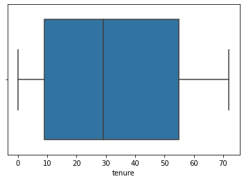

```
AxesSubplot(0.125,0.125;0.775x0.755)
```

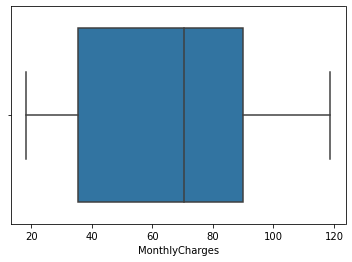

```
AxesSubplot(0.125,0.125;0.775x0.755)
```

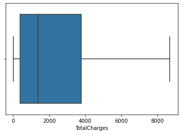

```python
#outliers analysis
for i , coltype in finaldf.dtypes.iteritems():
    if coltype != object:
        print(sns.boxplot(x=finaldf[i]))
        plt.show()
```

```python
finaldf = finaldf.drop('customerID',axis=1).copy() #Dropped customer ID as it is not required.
```

**Pie charts to for categorical features to see the percentage distribution of features**

```python
def Categorical_pie_charts1(data,m):
    a = []
    for i in data:
        a.append(i)

    b = []
    for i in a:
        if (data[i].dtype.name) == 'object':
            b.append(i)

    plt.figure(figsize=(20, 25))
    plt.subplots_adjust(hspace=0.5)
    plt.suptitle("Pie-Charts for Categorical Variables in the dataframe", fontsize=18, y=0.95)

    ncols = m
    nrows = len(b) // ncols + (len(b) % ncols > 0)

    for n, i in enumerate(b):
        ax = plt.subplot(nrows, ncols, n + 1)

        data.groupby(i).size().plot(kind='pie', autopct='%.2f%%',ax=ax)

        ax.set_title(i.upper())
        ax.set_xlabel("")
        ax.set_ylabel("")
    plt.show()
```

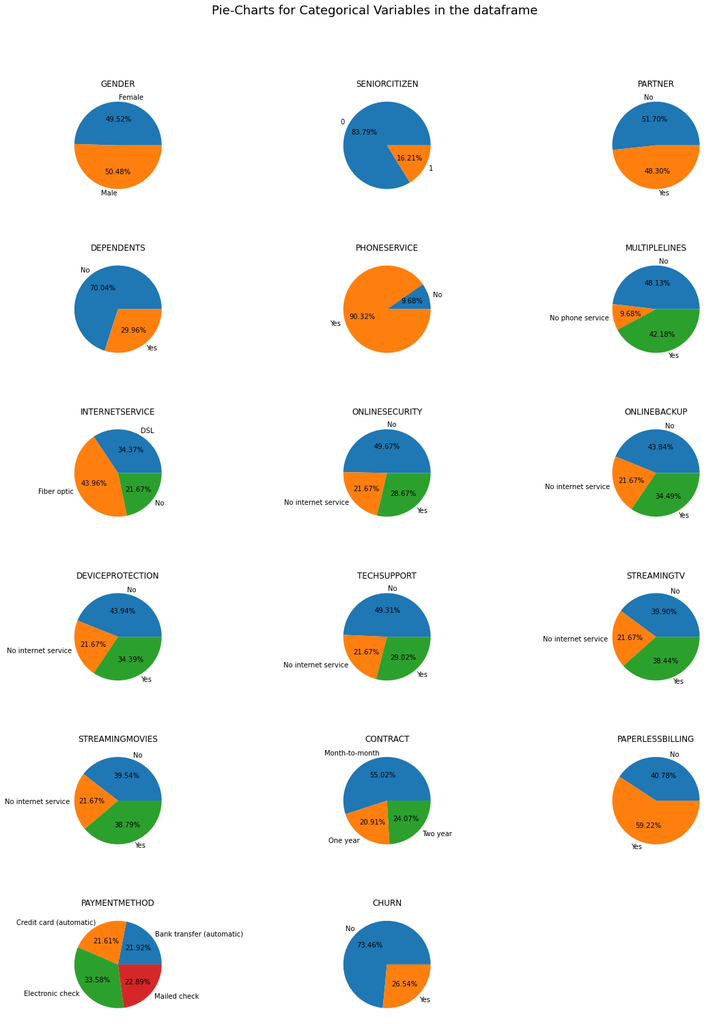

```python
Categorical_pie_charts1(finaldf,3)
```

**Encoding the dataframe features**

```python
#Defining the map function
def bin_map(feature):
    return feature.map({'Yes':1, 'No':0})

## Encoding target feature
finaldf['Churn'] = finaldf[['Churn']].apply(bin_map)

# Encoding gender category
finaldf['gender'] = finaldf['gender'].map({'Male':1, 'Female':0})

#Encoding other binary category
bin_list = ['Partner', 'Dependents', 'PhoneService', 'PaperlessBilling']
finaldf[bin_list] = finaldf[bin_list].apply(bin_map)

#Encoding the other categoric features with more than two categories
finaldf = pd.get_dummies(finaldf, drop_first=True)
```

```python
finaldf.head()
```

|  | gender | Partner | Dependents | tenure | PhoneService | PaperlessBilling | MonthlyCharges | TotalCharges | Churn | SeniorCitizen_1 | ... | TechSupport_Yes | StreamingTV_No internet service | StreamingTV_Yes | StreamingMovies_No internet service | StreamingMovies_Yes | Contract_One year | Contract_Two year | PaymentMethod_Credit card (automatic) | PaymentMethod_Electronic check | PaymentMethod_Mailed check |
| --- | --- | --- | --- | --- | --- | --- | --- | --- | --- | --- | --- | --- | --- | --- | --- | --- | --- | --- | --- | --- | --- |
| 0 | 0 | 1 | 0 | 1 | 0 | 1 | 29.85 | 29.85 | 0 | 0 | ... | 0 | 0 | 0 | 0 | 0 | 0 | 0 | 0 | 1 | 0 |
| 1 | 1 | 0 | 0 | 34 | 1 | 0 | 56.95 | 1889.50 | 0 | 0 | ... | 0 | 0 | 0 | 0 | 0 | 1 | 0 | 0 | 0 | 1 |
| 2 | 1 | 0 | 0 | 2 | 1 | 1 | 53.85 | 108.15 | 1 | 0 | ... | 0 | 0 | 0 | 0 | 0 | 0 | 0 | 0 | 0 | 1 |
| 3 | 1 | 0 | 0 | 45 | 0 | 0 | 42.30 | 1840.75 | 0 | 0 | ... | 1 | 0 | 0 | 0 | 0 | 1 | 0 | 0 | 0 | 0 |
| 4 | 0 | 0 | 0 | 2 | 1 | 1 | 70.70 | 151.65 | 1 | 0 | ... | 0 | 0 | 0 | 0 | 0 | 0 | 0 | 0 | 1 | 0 |

5 rows × 31 columns

```python
#correlation between features
corr = finaldf.corr()
corr
```

|  | gender | Partner | Dependents | tenure | PhoneService | PaperlessBilling | MonthlyCharges | TotalCharges | Churn | SeniorCitizen_1 | ... | TechSupport_Yes | StreamingTV_No internet service | StreamingTV_Yes | StreamingMovies_No internet service | StreamingMovies_Yes | Contract_One year | Contract_Two year | PaymentMethod_Credit card (automatic) | PaymentMethod_Electronic check | PaymentMethod_Mailed check |
| --- | --- | --- | --- | --- | --- | --- | --- | --- | --- | --- | --- | --- | --- | --- | --- | --- | --- | --- | --- | --- | --- |
| gender | 1.000000 | -0.001808 | 0.010517 | 0.005106 | -0.006488 | -0.011754 | -0.014569 | -0.000002 | -0.008612 | -0.001874 | ... | -0.009212 | 0.006026 | -0.008393 | 0.006026 | -0.010487 | 0.008026 | -0.003695 | 0.001215 | 0.000752 | 0.013744 |
| Partner | -0.001808 | 1.000000 | 0.452676 | 0.379697 | 0.017706 | -0.014877 | 0.096848 | 0.318364 | -0.150448 | 0.016479 | ... | 0.119999 | 0.000615 | 0.124666 | 0.000615 | 0.117412 | 0.082783 | 0.248091 | 0.082029 | -0.083852 | -0.095125 |
| Dependents | 0.010517 | 0.452676 | 1.000000 | 0.159712 | -0.001762 | -0.111377 | -0.113890 | 0.063593 | -0.164221 | -0.211185 | ... | 0.063268 | 0.139812 | -0.016558 | 0.139812 | -0.039741 | 0.068368 | 0.204613 | 0.060267 | -0.150642 | 0.059071 |
| tenure | 0.005106 | 0.379697 | 0.159712 | 1.000000 | 0.008448 | 0.006152 | 0.247900 | 0.825464 | -0.352229 | 0.016567 | ... | 0.324221 | -0.039062 | 0.279756 | -0.039062 | 0.286111 | 0.202570 | 0.558533 | 0.233006 | -0.208363 | -0.233852 |
| PhoneService | -0.006488 | 0.017706 | -0.001762 | 0.008448 | 1.000000 | 0.016505 | 0.247398 | 0.113013 | 0.011942 | 0.008576 | ... | -0.096340 | 0.172209 | -0.022574 | 0.172209 | -0.032959 | -0.002791 | 0.003519 | -0.007721 | 0.003062 | -0.003319 |
| PaperlessBilling | -0.011754 | -0.014877 | -0.111377 | 0.006152 | 0.016505 | 1.000000 | 0.352150 | 0.158055 | 0.191825 | 0.156530 | ... | 0.037880 | -0.321013 | 0.223841 | -0.321013 | 0.211716 | -0.051391 | -0.147889 | -0.013589 | 0.208865 | -0.205398 |
| MonthlyCharges | -0.014569 | 0.096848 | -0.113890 | 0.247900 | 0.247398 | 0.352150 | 1.000000 | 0.650864 | 0.193356 | 0.220173 | ... | 0.338304 | -0.763557 | 0.629603 | -0.763557 | 0.627429 | 0.004904 | -0.074681 | 0.030550 | 0.271625 | -0.377437 |
| TotalCharges | -0.000002 | 0.318364 | 0.063593 | 0.825464 | 0.113013 | 0.158055 | 0.650864 | 1.000000 | -0.199037 | 0.102652 | ... | 0.432329 | -0.374706 | 0.515279 | -0.374706 | 0.519884 | 0.170649 | 0.356226 | 0.182745 | -0.059971 | -0.294814 |
| Churn | -0.008612 | -0.150448 | -0.164221 | -0.352229 | 0.011942 | 0.191825 | 0.193356 | -0.199037 | 1.000000 | 0.150889 | ... | -0.164674 | -0.227890 | 0.063228 | -0.227890 | 0.061382 | -0.177820 | -0.302253 | -0.134302 | 0.301919 | -0.091683 |
| SeniorCitizen_1 | -0.001874 | 0.016479 | -0.211185 | 0.016567 | 0.008576 | 0.156530 | 0.220173 | 0.102652 | 0.150889 | 1.000000 | ... | -0.060625 | -0.182742 | 0.105378 | -0.182742 | 0.120176 | -0.046262 | -0.117000 | -0.024135 | 0.171718 | -0.153477 |
| MultipleLines_No phone service | 0.006488 | -0.017706 | 0.001762 | -0.008448 | -1.000000 | -0.016505 | -0.247398 | -0.113013 | -0.011942 | -0.008576 | ... | 0.096340 | -0.172209 | 0.022574 | -0.172209 | 0.032959 | 0.002791 | -0.003519 | 0.007721 | -0.003062 | 0.003319 |
| MultipleLines_Yes | -0.008414 | 0.142057 | -0.024526 | 0.331941 | 0.279690 | 0.163530 | 0.490434 | 0.468705 | 0.040102 | 0.142948 | ... | 0.100571 | -0.210564 | 0.257152 | -0.210564 | 0.258751 | -0.003794 | 0.106253 | 0.060048 | 0.083618 | -0.227206 |
| InternetService_Fiber optic | -0.011286 | 0.000304 | -0.165818 | 0.019720 | 0.289999 | 0.326853 | 0.787066 | 0.361045 | 0.308020 | 0.255338 | ... | -0.020492 | -0.465793 | 0.329349 | -0.465793 | 0.322923 | -0.076324 | -0.211526 | -0.050077 | 0.336410 | -0.306834 |
| InternetService_No | 0.006026 | 0.000615 | 0.139812 | -0.039062 | 0.172209 | -0.321013 | -0.763557 | -0.374706 | -0.227890 | -0.182742 | ... | -0.336298 | 1.000000 | -0.415552 | 1.000000 | -0.418675 | 0.038004 | 0.218278 | 0.001030 | -0.284917 | 0.321361 |
| OnlineSecurity_No internet service | 0.006026 | 0.000615 | 0.139812 | -0.039062 | 0.172209 | -0.321013 | -0.763557 | -0.374706 | -0.227890 | -0.182742 | ... | -0.336298 | 1.000000 | -0.415552 | 1.000000 | -0.418675 | 0.038004 | 0.218278 | 0.001030 | -0.284917 | 0.321361 |
| OnlineSecurity_Yes | -0.017021 | 0.143106 | 0.080972 | 0.327203 | -0.092893 | -0.003636 | 0.296594 | 0.412091 | -0.171226 | -0.038653 | ... | 0.354931 | -0.333403 | 0.176207 | -0.333403 | 0.187398 | 0.100162 | 0.191773 | 0.115721 | -0.112338 | -0.080798 |
| OnlineBackup_No internet service | 0.006026 | 0.000615 | 0.139812 | -0.039062 | 0.172209 | -0.321013 | -0.763557 | -0.374706 | -0.227890 | -0.182742 | ... | -0.336298 | 1.000000 | -0.415552 | 1.000000 | -0.418675 | 0.038004 | 0.218278 | 0.001030 | -0.284917 | 0.321361 |
| OnlineBackup_Yes | -0.013773 | 0.141498 | 0.023671 | 0.360277 | -0.052312 | 0.126735 | 0.441780 | 0.509607 | -0.082255 | 0.066572 | ... | 0.294233 | -0.381593 | 0.282106 | -0.381593 | 0.274501 | 0.083722 | 0.111400 | 0.090785 | -0.000408 | -0.174164 |
| DeviceProtection_No internet service | 0.006026 | 0.000615 | 0.139812 | -0.039062 | 0.172209 | -0.321013 | -0.763557 | -0.374706 | -0.227890 | -0.182742 | ... | -0.336298 | 1.000000 | -0.415552 | 1.000000 | -0.418675 | 0.038004 | 0.218278 | 0.001030 | -0.284917 | 0.321361 |
| DeviceProtection_Yes | -0.002105 | 0.153786 | 0.013963 | 0.360653 | -0.071227 | 0.103797 | 0.482692 | 0.522374 | -0.066160 | 0.059428 | ... | 0.333313 | -0.380754 | 0.390874 | -0.380754 | 0.402111 | 0.102495 | 0.165096 | 0.111554 | -0.003351 | -0.187373 |
| TechSupport_No internet service | 0.006026 | 0.000615 | 0.139812 | -0.039062 | 0.172209 | -0.321013 | -0.763557 | -0.374706 | -0.227890 | -0.182742 | ... | -0.336298 | 1.000000 | -0.415552 | 1.000000 | -0.418675 | 0.038004 | 0.218278 | 0.001030 | -0.284917 | 0.321361 |
| TechSupport_Yes | -0.009212 | 0.119999 | 0.063268 | 0.324221 | -0.096340 | 0.037880 | 0.338304 | 0.432329 | -0.164674 | -0.060625 | ... | 1.000000 | -0.336298 | 0.278070 | -0.336298 | 0.279358 | 0.095775 | 0.240824 | 0.117272 | -0.114839 | -0.085509 |
| StreamingTV_No internet service | 0.006026 | 0.000615 | 0.139812 | -0.039062 | 0.172209 | -0.321013 | -0.763557 | -0.374706 | -0.227890 | -0.182742 | ... | -0.336298 | 1.000000 | -0.415552 | 1.000000 | -0.418675 | 0.038004 | 0.218278 | 0.001030 | -0.284917 | 0.321361 |
| StreamingTV_Yes | -0.008393 | 0.124666 | -0.016558 | 0.279756 | -0.022574 | 0.223841 | 0.629603 | 0.515279 | 0.063228 | 0.105378 | ... | 0.278070 | -0.415552 | 1.000000 | -0.415552 | 0.533094 | 0.061612 | 0.072049 | 0.040433 | 0.144626 | -0.247742 |
| StreamingMovies_No internet service | 0.006026 | 0.000615 | 0.139812 | -0.039062 | 0.172209 | -0.321013 | -0.763557 | -0.374706 | -0.227890 | -0.182742 | ... | -0.336298 | 1.000000 | -0.415552 | 1.000000 | -0.418675 | 0.038004 | 0.218278 | 0.001030 | -0.284917 | 0.321361 |
| StreamingMovies_Yes | -0.010487 | 0.117412 | -0.039741 | 0.286111 | -0.032959 | 0.211716 | 0.627429 | 0.519884 | 0.061382 | 0.120176 | ... | 0.279358 | -0.418675 | 0.533094 | -0.418675 | 1.000000 | 0.064926 | 0.073960 | 0.048575 | 0.137966 | -0.250595 |
| Contract_One year | 0.008026 | 0.082783 | 0.068368 | 0.202570 | -0.002791 | -0.051391 | 0.004904 | 0.170649 | -0.177820 | -0.046262 | ... | 0.095775 | 0.038004 | 0.061612 | 0.038004 | 0.064926 | 1.000000 | -0.289510 | 0.067589 | -0.109130 | -0.000116 |
| Contract_Two year | -0.003695 | 0.248091 | 0.204613 | 0.558533 | 0.003519 | -0.147889 | -0.074681 | 0.356226 | -0.302253 | -0.117000 | ... | 0.240824 | 0.218278 | 0.072049 | 0.218278 | 0.073960 | -0.289510 | 1.000000 | 0.173265 | -0.282138 | -0.004705 |
| PaymentMethod_Credit card (automatic) | 0.001215 | 0.082029 | 0.060267 | 0.233006 | -0.007721 | -0.013589 | 0.030550 | 0.182745 | -0.134302 | -0.024135 | ... | 0.117272 | 0.001030 | 0.040433 | 0.001030 | 0.048575 | 0.067589 | 0.173265 | 1.000000 | -0.373322 | -0.286049 |
| PaymentMethod_Electronic check | 0.000752 | -0.083852 | -0.150642 | -0.208363 | 0.003062 | 0.208865 | 0.271625 | -0.059971 | 0.301919 | 0.171718 | ... | -0.114839 | -0.284917 | 0.144626 | -0.284917 | 0.137966 | -0.109130 | -0.282138 | -0.373322 | 1.000000 | -0.387372 |
| PaymentMethod_Mailed check | 0.013744 | -0.095125 | 0.059071 | -0.233852 | -0.003319 | -0.205398 | -0.377437 | -0.294814 | -0.091683 | -0.153477 | ... | -0.085509 | 0.321361 | -0.247742 | 0.321361 | -0.250595 | -0.000116 | -0.004705 | -0.286049 | -0.387372 | 1.000000 |

31 rows × 31 columns

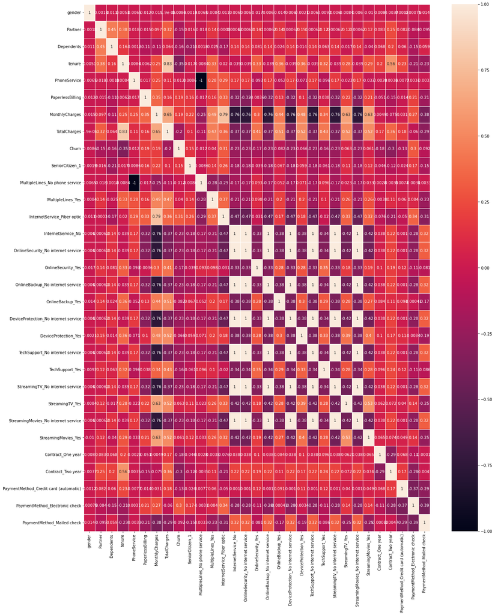

```python
##Heatmap for Correlation
fig, ax = plt.subplots(figsize=(20,25))
sns.heatmap(corr, annot=True, linewidths= .5, ax=ax)
```

**Normalize/Standardize the data**

```python
scaler = MinMaxScaler()
finaldf['tenure'] = scaler.fit_transform(finaldf[['tenure']])
finaldf['MonthlyCharges'] = scaler.fit_transform(finaldf[['MonthlyCharges']])
finaldf['TotalCharges'] = scaler.fit_transform(finaldf[['TotalCharges']])
```

**Creating preprocessing fuction calling all preprocessing related function within it**

```python
import pandas as pd
from sklearn.preprocessing import MinMaxScaler

def preprocessing_(finaldf, option):

    #Defining the map function
    def bin_map(feature):
        return feature.map({'Yes':1, 'No':0})
        finaldf['Churn'] = finaldf[['Churn']].apply(bin_map)

        finaldf['gender'] = finaldf['gender'].map({'Male':1, 'Female':0})

        bin_list = ['Partner', 'Dependents', 'PhoneService', 'PaperlessBilling']
        finaldf[bin_list] = finaldf[bin_list].apply(bin_map)


        finaldf = pd.get_dummies(finaldf, drop_first=True)

    #feature scaling
    sc = MinMaxScaler()
    finaldf['tenure'] = sc.fit_transform(finaldf[['tenure']])
    finaldf['MonthlyCharges'] = sc.fit_transform(finaldf[['MonthlyCharges']])
    finaldf['TotalCharges'] = sc.fit_transform(finaldf[['TotalCharges']])

    return finaldf
```

**Splitting the data in 70:30 ratio**

```python
from sklearn.linear_model import LogisticRegression
from sklearn.svm import SVC
from sklearn.ensemble import RandomForestClassifier
from sklearn.tree import DecisionTreeClassifier
from sklearn.naive_bayes import GaussianNB

#Import metric for performance evaluation
from sklearn.metrics import accuracy_score, precision_score, recall_score, f1_score

X = finaldf.drop('Churn', axis=1)
y = finaldf['Churn']
X_train, X_test, y_train, y_test = train_test_split(X, y, test_size=0.3, random_state=50)
```

**Function to predict various model scores**

```python
def modeling(alg, alg_name, params={}):
    model = alg(**params)
    model.fit(X_train, y_train)
    y_pred = model.predict(X_test)

    #Performance evaluation
    def print_scores(alg, y_true, y_pred):
        print(alg_name)
        acc_score = accuracy_score(y_true, y_pred)
        print("accuracy: ",acc_score)
        pre_score = precision_score(y_true, y_pred)
        print("precision: ",pre_score)
        rec_score = recall_score(y_true, y_pred)
        print("recall: ",rec_score)
        f_score = f1_score(y_true, y_pred, average='weighted')
        print("f1_score: ",f_score)

    print_scores(alg, y_test, y_pred)
    return model
```

**Logistic Regression Model**

```python
logres_model = modeling(LogisticRegression, 'Logistic Regression')
```

```
Logistic Regression
accuracy:  0.7983909133932797
precision:  0.6281800391389433
recall:  0.5763016157989228
f1_score:  0.7955174819104321
```

**SVC Model**

```python
svc_model = modeling(SVC, 'SVC Classification')
```

```
SVC Classification
accuracy:  0.795551348793185
precision:  0.6355748373101953
recall:  0.526032315978456
f1_score:  0.7889704158679894
```

**Randomforest model**

```python
rfc_model = modeling(RandomForestClassifier, "Random Forest Classification")
```

```
Random Forest Classification
accuracy:  0.7884524372929484
precision:  0.6200873362445415
recall:  0.5098743267504489
f1_score:  0.7813967518148024
```

**Decision tree model**

```python
dt_model = modeling(DecisionTreeClassifier, "Decision Tree Classification")
```

```
Decision Tree Classification
accuracy:  0.7269285376242309
precision:  0.4834983498349835
recall:  0.526032315978456
f1_score:  0.7304969027795833
```

**Naive Bayes Model**

```python
#Naive bayes
nb_model = modeling(GaussianNB, "Naive Bayes Classification")
```

```
Naive Bayes Classification
accuracy:  0.6469474680548982
precision:  0.42011834319526625
recall:  0.8922800718132855
f1_score:  0.6660052398768987
```

Based on above models "Logistic regression" is the best model with highest accuracy score

**Hyperparameter Tuning for Logistic Regression Model**

```python
from sklearn.model_selection import GridSearchCV
##Defining paramters and grid
grid1={'solver': ('liblinear', 'newton-cg', 'lbfgs', 'sag', 'saga'),"penalty":["l1","l2"],"C":[-1,0,1,10,100]}

logres=LogisticRegression() #model
logres_cv=GridSearchCV(logres,grid1,cv=10)
logres_cv.fit(X_train, y_train)

#summarizing results

print("Best parameters :",logres_cv.best_params_)
print("accuracy :",logres_cv.score(X_test,y_test))
```

```
Best parameters : {'C': 10, 'penalty': 'l2', 'solver': 'liblinear'}
accuracy : 0.8002839564600095
```

```python
params = logres_cv.best_params_
params
```

```
{'C': 10, 'penalty': 'l2', 'solver': 'liblinear'}
```

**Final Model using best parameters suggested after hypertuning of parameters**

```python
logres_model = modeling(LogisticRegression, 'Logistic Regression Classification', params=params)
```

```
Logistic Regression Classification
accuracy:  0.8002839564600095
precision:  0.6326129666011788
recall:  0.578096947935368
f1_score:  0.7973043659275131
```

**Saving Model as Pickle file**

```python
import pickle
with open('model_pkl', 'wb') as files:
    pickle.dump(logres_model, files)
```

""

# **Research References:**

**--->Create/define fuctions in python:** https://www.earthdatascience.org/courses/intro-to-earth-data-science/write-efficient-python-code/functions-modular-code/write-functions-with-multiple-and-optional-parameters-in-python/

**--->Create/define fuctions in python:** https://www.w3schools.com/python/python_functions.asp

**--->Data Preprocessing/Scaling/normalization/Encoding:** https://scikit-learn.org/stable/modules/preprocessing.html

**--->XGboost classifier: 1.)** https://xgboost.readthedocs.io/en/stable/

**2.)** https://towardsdatascience.com/beginners-guide-to-xgboost-for-classification-problems-50f75aac5390

**3.)** https://www.geeksforgeeks.org/xgboost/

**--->Hyperparameter tuning: 1.)** https://machinelearningmastery.com/hyperparameter-optimization-with-random-search-and-grid-search/

**2.)** https://towardsdatascience.com/hyperparameter-tuning-for-machine-learning-models-1b80d783b946

**--->Saving Model as pickle file or by other methods:** https://www.analyticsvidhya.com/blog/2021/08/quick-hacks-to-save-machine-learning-model-using-pickle-and-joblib/